# Musterlösung: Übungsaufgabe 4

Statistische Modellbildung II

21.November 2018

**Datenaufbereitung aus vorheriger Woche**

```r
*Alter.
compute alter0= v84-18.
variable labels alter0 "Alter mit 18 als Nullpunkt".

frequencies alter0.


*Bildung.
Recode v86 (1=0) (2=1) (3=2) (4=3) (5=4) (else=SYSMIS) into bildung_rec.
variable labels bildung_rec "Abschluss umkodiert".
value labels bildung_rec 0"Kein Schulabschluss" 1"Hauptschule" 2"Realschule" 3"Fachhochschulreife" 4"Abi".

frequencies bildung_rec.


*Geschlecht.
Recode v81 (2=0) (1=1) (else=copy) into geschl_rec.
variable labels geschl_rec "Geschlecht mit w=0".
value labels geschl_rec 0"weiblich" 1"mÃ¤nnlich".

frequencies geschl_rec.


*Einkommen.
COMPUTE einkommen = v420.

frequencies einkommen.
```

## Aufgabe 1

*Erstellen Sie ein Streudiagramm zwischen den Residuen der Regression von “prestige_befragter” auf “bildung_befragter” und der Variablen “bildung_befragter”. Beschreiben Sie das Diagramm, sprich wie die fünf “Streusäulen” in Relation zueinander aussehen. Äußern Sie eine Vermutung ob dies bereits eine Verletzung der A1 ist und begründen Sie diese kurz*

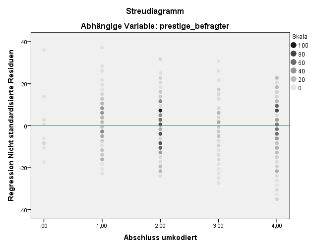

```r
*siops.
COMPUTE prestige_befragter = V112.

REGRESSION
  /DEPENDENT prestige_befragter
  /METHOD=ENTER bildung_rec
  /SCATTERPLOT=(*RESID ,bildung_rec).
```

## Aufgabe 2

*Erstellen Sie eine Regression von Einkommen auf Alter (Alter_0) und speichern Sie dabei die unstandardisierten sowie die standardisierte Residuen aus. Erstellen Sie anschließend ein Streudiagramm für die beiden unterschiedlichen Residuenarten. Die UV soll hierbei das Alter der Befragten sein.*

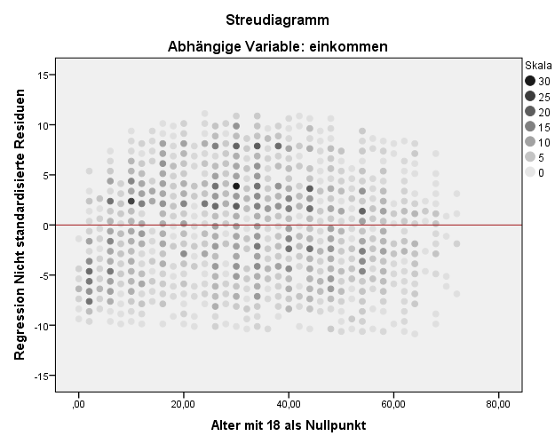

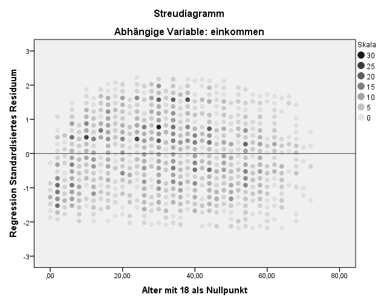

```r
REGRESSION
  /DEPENDENT einkommen
  /METHOD=ENTER alter0
  /SAVE RESID ZRESID
  /SCATTERPLOT=(*RESID , alter0)
  /SCATTERPLOT=(*ZRESID , alter0).
```

### Aufgabe 2a

*Was ist der Unterschied zwischen den beiden Residuenarten und wie werden die standardisierten Residuen gebildet?*

Die standardisierten Residuen sind z-standardisierte Residuen, zeigen also die standardisierten Abstände zur Regressionsgeraden, während die unstandardisierten Residuen absolute Fehlerwerte sind.

### Aufgabe 2b

*Beschreiben Sie die beiden Streudiagramme. Gibt es Unterschiede, falls nein, hängt dies mit der Art der Erstellung der Variablen zusammen? Beziehen Sie sich bei Ihrer Antwort auf die statistischen Kenngrößen, die mittels FREQ-Befehl ausgegeben werden.*

```r
FREQUENCIES ZRE_1
/STATISTICS = MEAN STDDEV KURTOSIS SKEWNESS
/FORMAT = NOTABLE.
```

[output not shown]

Visuell gibt es keine nennenswerten unterschiede zwischen den beiden Streudiagrammen. Aufgrund der Standardisierung kann die Varianzstreuung in der Regel besser eingeschätzt werden, weil die Abstände nicht absolut sind, sondern standardisiert. Beide Residuenarten zeigen einen Mittelwert von 0, weil Residuen die Abstände zur Regressionsgeraden aufzeigen. Auch bei unstandardisierten Residuen ist der Mittelwert 0, allerdings unterscheidet sich die Standardabweichung.

## Aufgabe 3

*Anhand der Scatterplots (Streudiagramme) lässt sich vermuten, dass zwischen verschiedenen Altersgruppen Varianzinhomogenität (Verletzung A1) besteht.*

### Aufgabe 3a

*Erläutern Sie das Prinzip nach welchem der Test funktioniert, der angewendet werden muss, um zu prüfen, ob die identifizierten Gruppen Varianzhomogenität aufweisen.*

Zunächst ist eine visuelle Überprüfung der Varianz der Residuen zu empfehlen. Nachdem man bei der Überprüfung des Streudiagramms eine Verletzung der A1 Annahme vermutet, sollte man den sogenannten *Levene-Test* anwenden.

Für einen Levene-Test werden zunÄchst Gruppen gebildet, welche die Bereiche der unterschiedlichen Streuungen möglichst genau abgrenzen sollen. Mit diesen Variablen wird der Levene-Test durchgeführt. Es wird untersucht, ob die Varianz innerhalb der Gruppen signifikant voneinander abweicht. Wird das Testergebnis also signifikant, so kann von einer signifikanten Abweichung der Varianzen in den verschiedenen Gruppen ausgegangen werden (Heteroskedastizität) und so kann die Annahme 1 als verletzt gesehen werden.

### Aufgabe 3b

*Testen Sie die Annahme A3 und A5 (Test der Gesamtheit der Residuen) für die Residuen von Aufgabe 3. Sind die Annahmen erfüllt? Welche Einschränkungen müssen bzgl. des Tests für A5 beachtet werden?*

Test von Annahme 3

Zuerst eine absolute Residuenvariable erstellen und dann eine Korrelation anzeigen:

```r
COMPUTE ZRE_1_ABS = ABS(ZRE_1).
CORR alter0 ZRE_1_ABS.
```

KorrelationenKorrelationen, Tabelle, 1 Stufen von Spaltenüberschriften und 2 Stufen von Zeilenüberschriften, Tabelle mit 4 Spalten und 8 Zeilen

|  |  | Alter mit 18 als Nullpunkt | ZRE_1_ABS |
| --- | --- | --- | --- |
| Alter mit 18 als Nullpunkt | Korrelation nach Pearson | 1 | -,045 |
|  | Signifikanz (2-seitig) |  | ,012 |
|  | N | 3468 | 3064 |
| ZRE_1_ABS | Korrelation nach Pearson | -,045 | 1 |
|  | Signifikanz (2-seitig) | ,012 |  |
|  | N | 3064 | 3064 |

Die Standardisierten Residuen der Regression von Einkommen auf alter0 sind signifikant mit alter0 korreliert. Allerdings ist diese Korrelation relativ gering, daher kann die A3 als nicht verletzt gelten. Eine genauere Inspizion des Sachverhalts wäre angebracht.

Test von Annahme 5

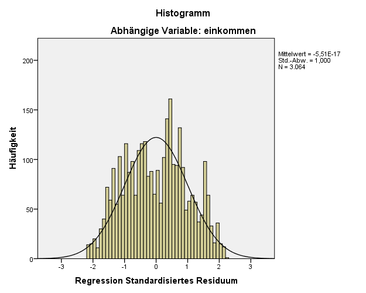

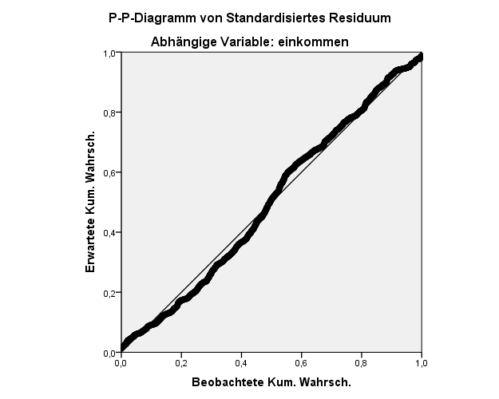

Tests auf NormalverteilungTests auf Normalverteilung, Tabelle, 2 Stufen von Spaltenüberschriften und 1 Stufen von Zeilenüberschriften, Tabelle mit 7 Spalten und 5 Zeilen

|  | Kolmogorov-Smirnov<sup>a</sup> |  |  | Shapiro-Wilk |  |  |
| --- | --- | --- | --- | --- | --- | --- |
|  | Statistik | df | Signifikanz | Statistik | df | Signifikanz |
| Standardized Residual | ,047 | 3064 | ,000 | ,982 | 3064 | ,000 |

a. Signifikanzkorrektur nach Lilliefors